[output not shown]

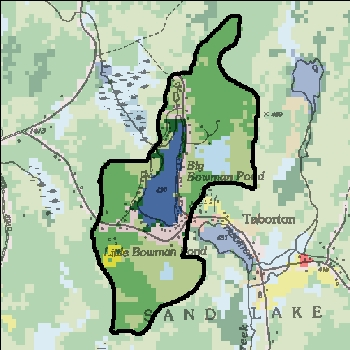

## Big Bowman Pond – 2018 Sampling Season Results

Open Water Indicators

2018 Sampling Results

Seasonal Change

Season Avg

Decadal Average

Decadal Trend?

Longterm Avg

Longterm Trend?

06-17

07-01

07-16

07-29

08-12

08-26

09-09

09-23

Clarity (m)

3.6

3.8

2.5

2

1.6

1.3

1.2

1.4

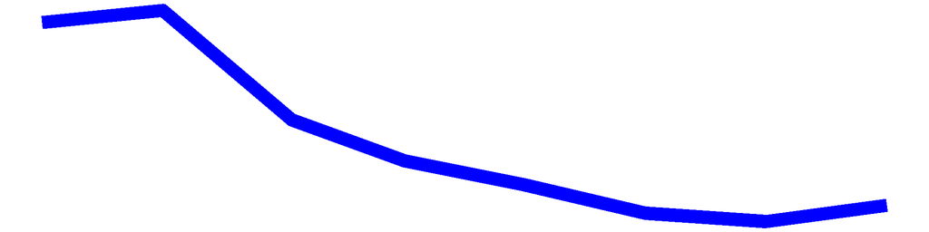

2.3

2.1

2.1

Surface TP (mg/L)

0.008

0.006

0.004

0.009

0.009

0.012

0.017

0.011

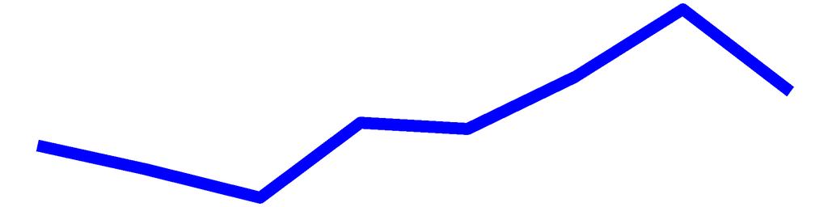

0.009

0.014

0.014

Surface TDP (mg/L)

0.004

0.002

0.004

0.005

0.006

0.008

0.002

0.01

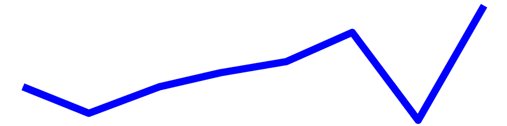

0.005

TN (mg/L)

0.321

0.309

0.316

0.43

0.388

0.412

0.417

0.361

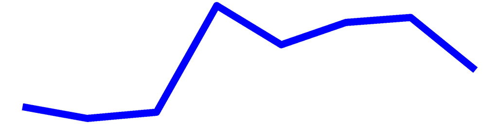

0.369

0.325

0.325

TDN (mg/L)

0.33

0.299

0.343

0.385

0.419

0.367

0.413

0.324

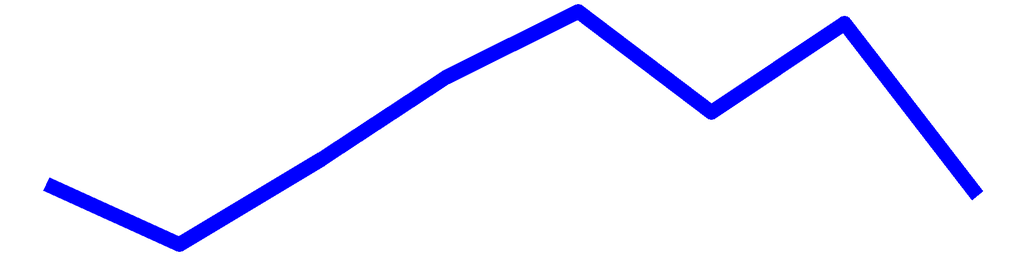

0.36

0.239

0.239

TN:TP

42

51

75

47

44

33

25

32

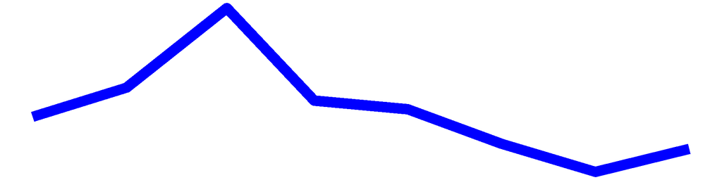

44

24

24

Surface NH3 (mg/L)

0.116

0.03

0.015

0.021

0.011

0.013

0.005

0.022

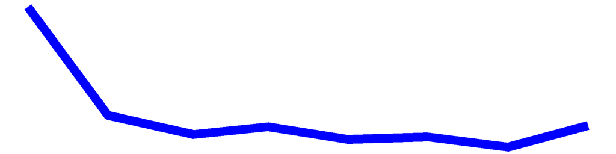

0.029

0.018

0.018

Chl.a (ug/L)

1.2

0.6

1.8

5.3

8.1

10

7.1

6.4

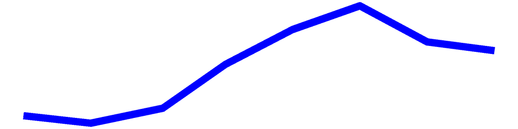

4.6

7.3

7.3

pH

6.7

7.1

7.1

7

6.7

7.1

7.7

7

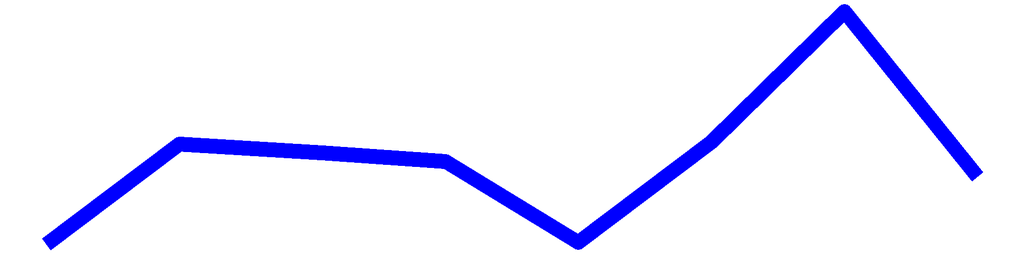

7

7.3

7.3

Cond (umho/cm)

108

196

202

136

126

133

87

137

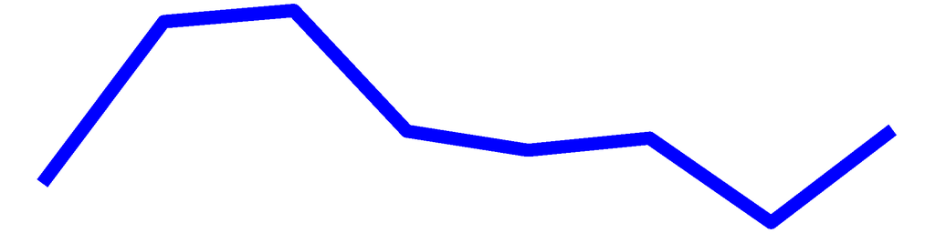

141

131

131

Surface Chloride (mg/L)

24

24

34

34

Upper Temp (degC)

22

30

28

24

23

24

21

22

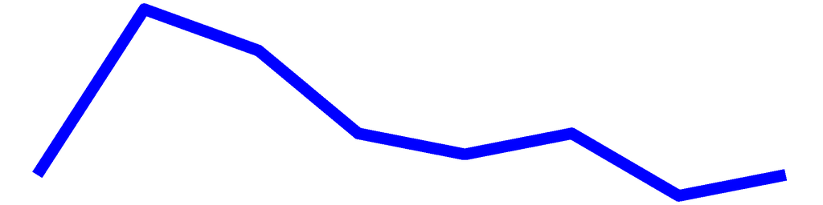

24

22

22

FP BG Chl.a (ug/L)

0.1

0.2

0

0.7

0.9

1.1

0.3

0.4

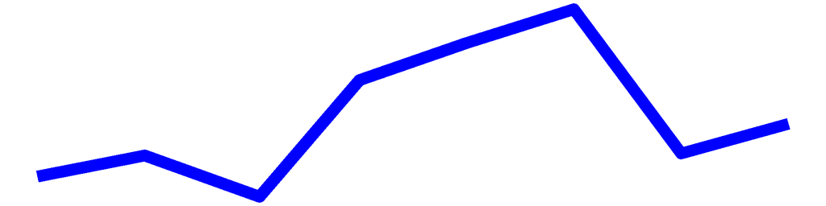

0.5

0.3

0.3

### NYHABs notifications

#### Were there any reported HABs this season? **Yes.**

[output not shown]

### Shoreline HAB Sample Dates 2018

| HAB Indicators | Criteria | 06-17 |
| --- | --- | --- |
| FP BGA Chl. a | 25 ug/L | 34.98 |
| Microcystin | 20 ug/L | ND |
| Microscopy | Dominant | Planktothrix, Tabellaria, Fragilaria, Microspora, Synedra, Asterionella, Staurastrum, Spirogyra, Mougeotia |

### HABs Status

#### Open Water Algae

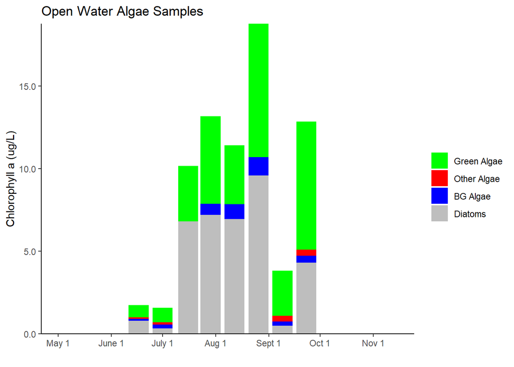

#### Shoreline Algae

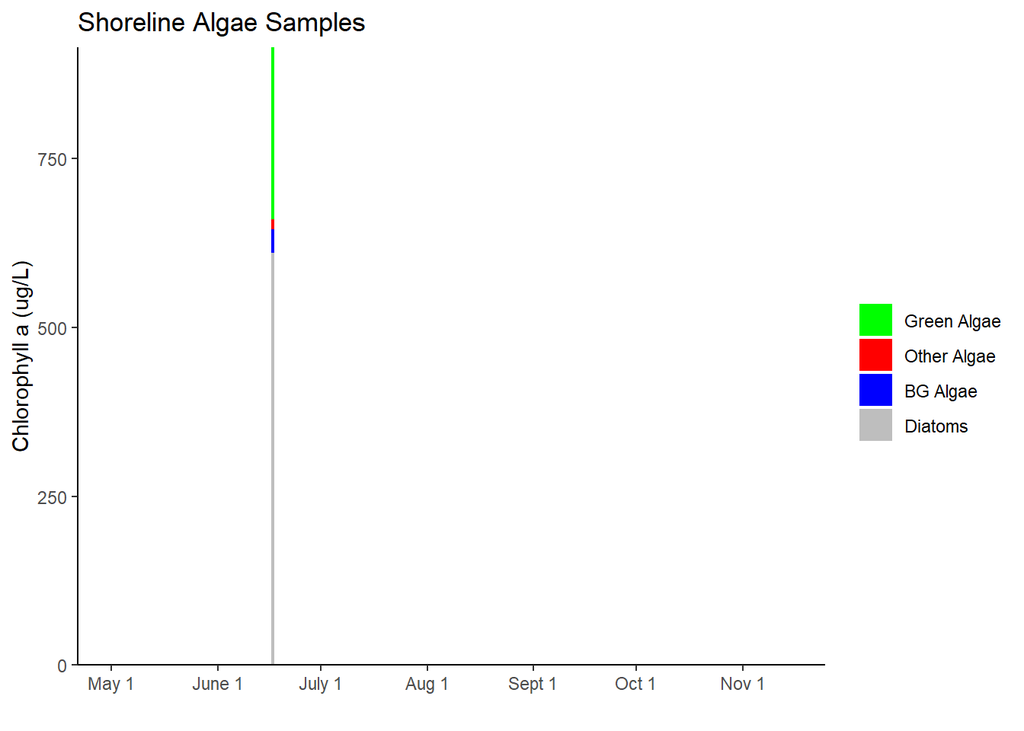

## Big Bowman Pond Long-Term Trend Analysis

#### Clarity

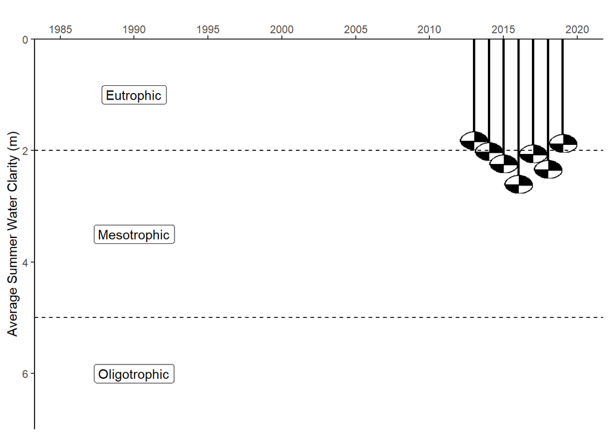

#### Chlorophyll *a*

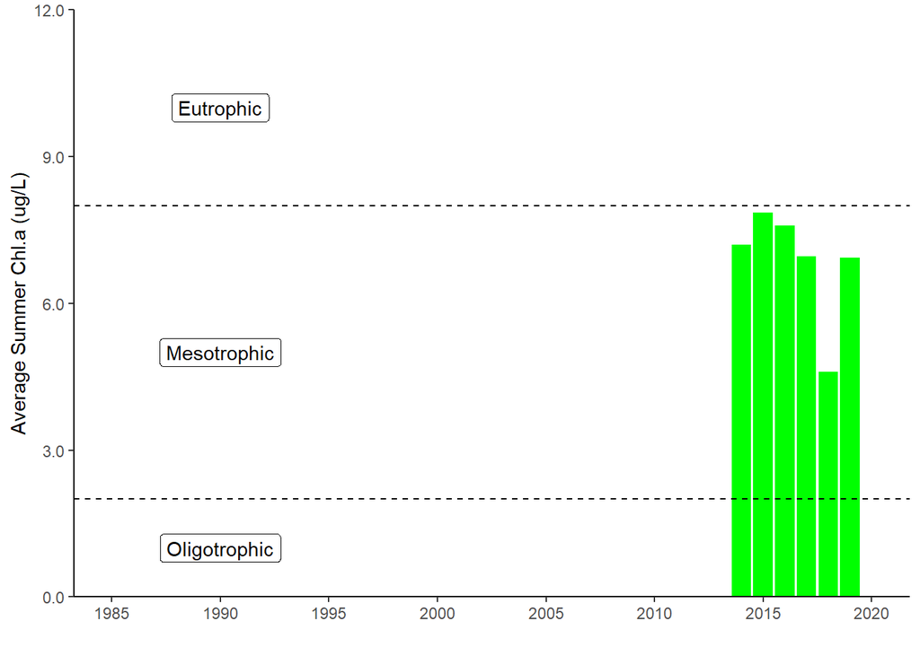

#### Surface and Deep Phosphorus

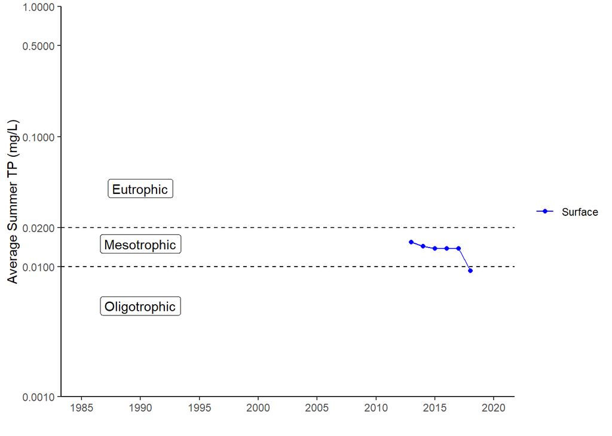

#### Nitrogen

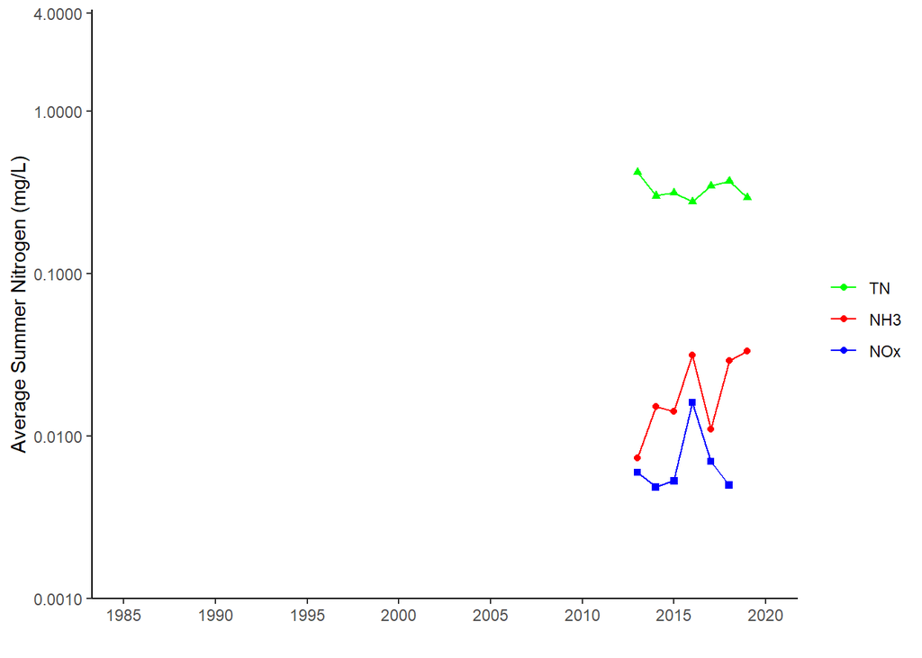

#### TN : TP

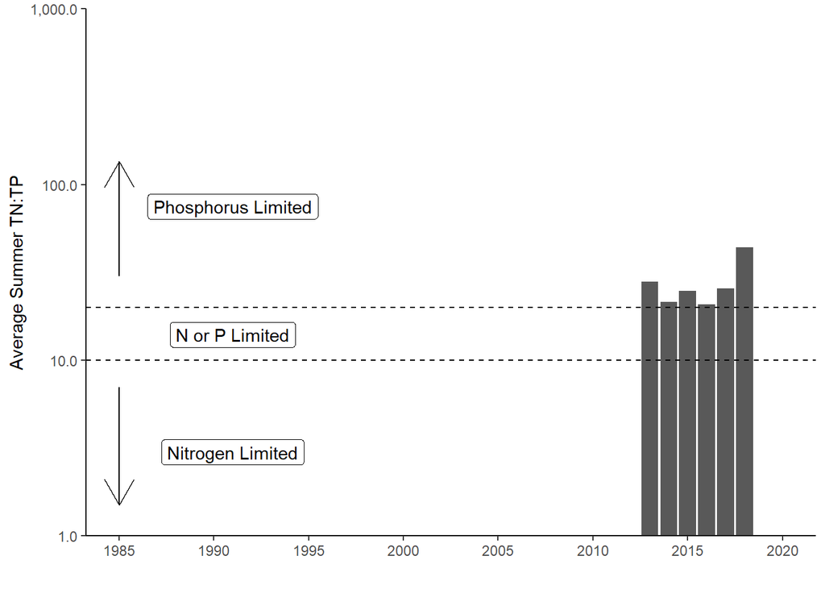

#### pH

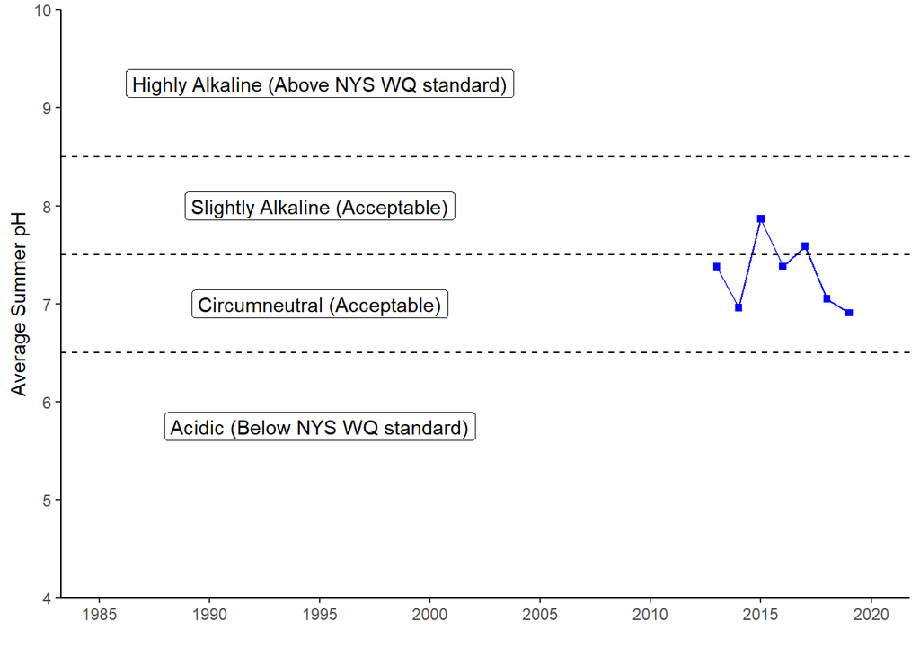

#### Specific Conductance

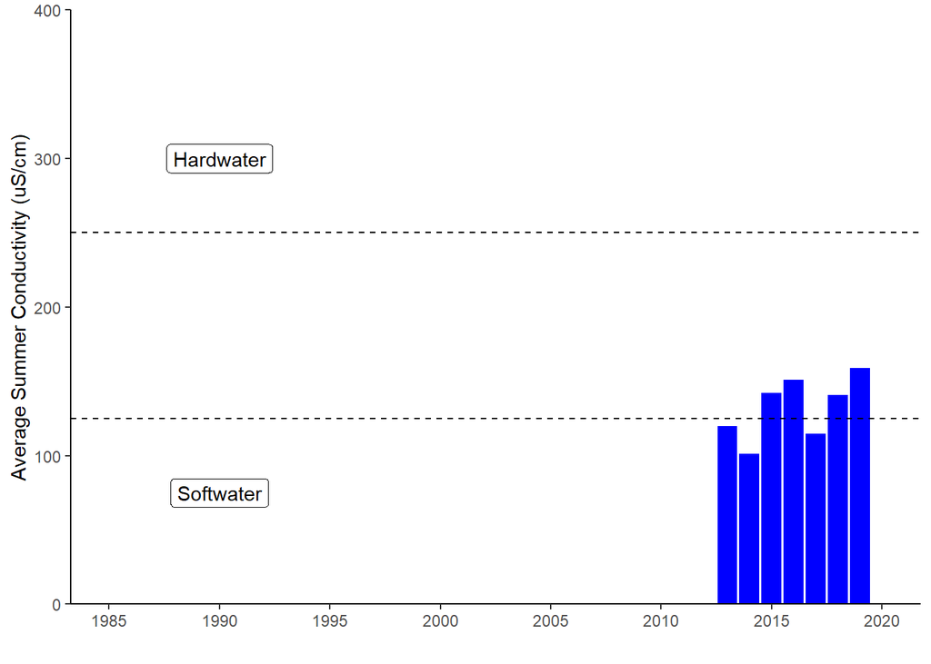

#### Calcium

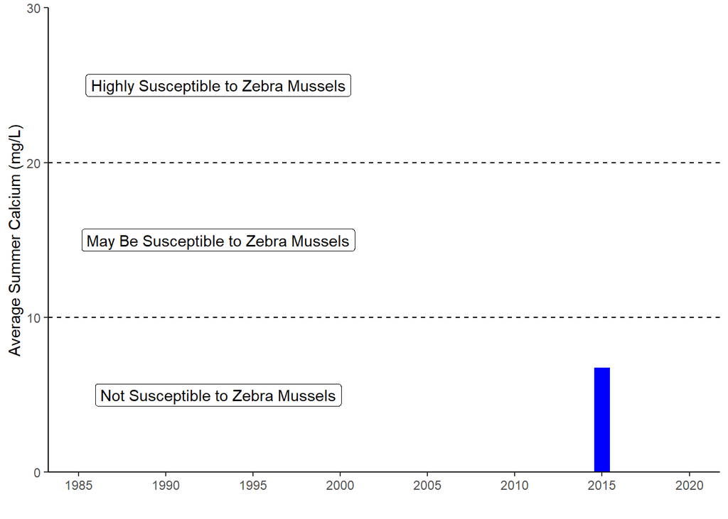

#### Chloride

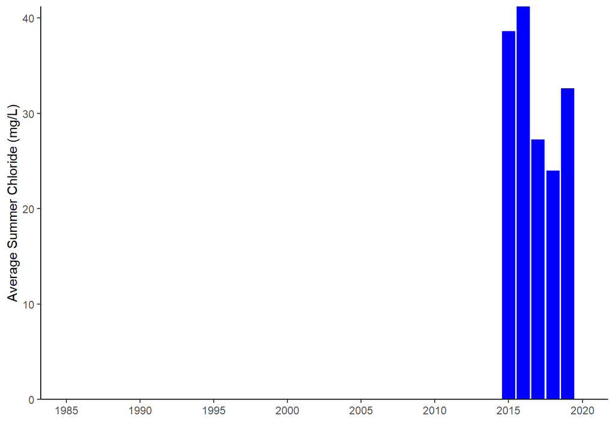

#### Color

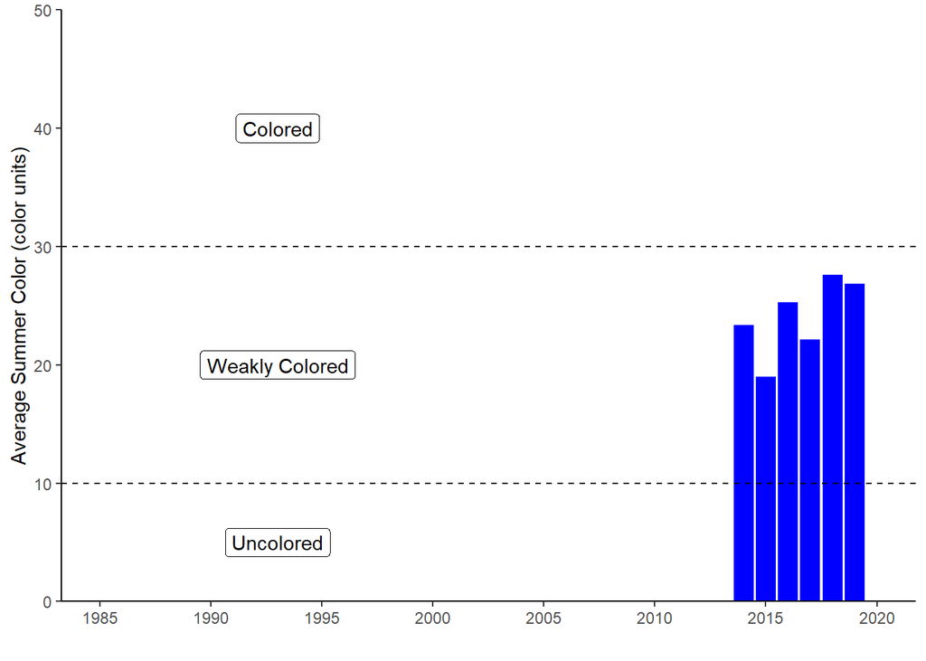

#### Surface and Deep Temperature

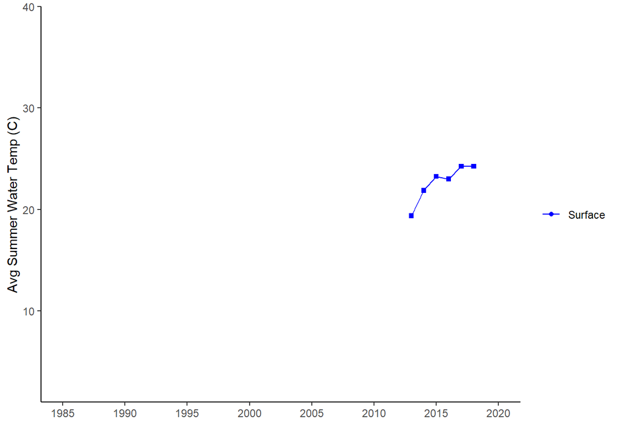

#### Lake Perception

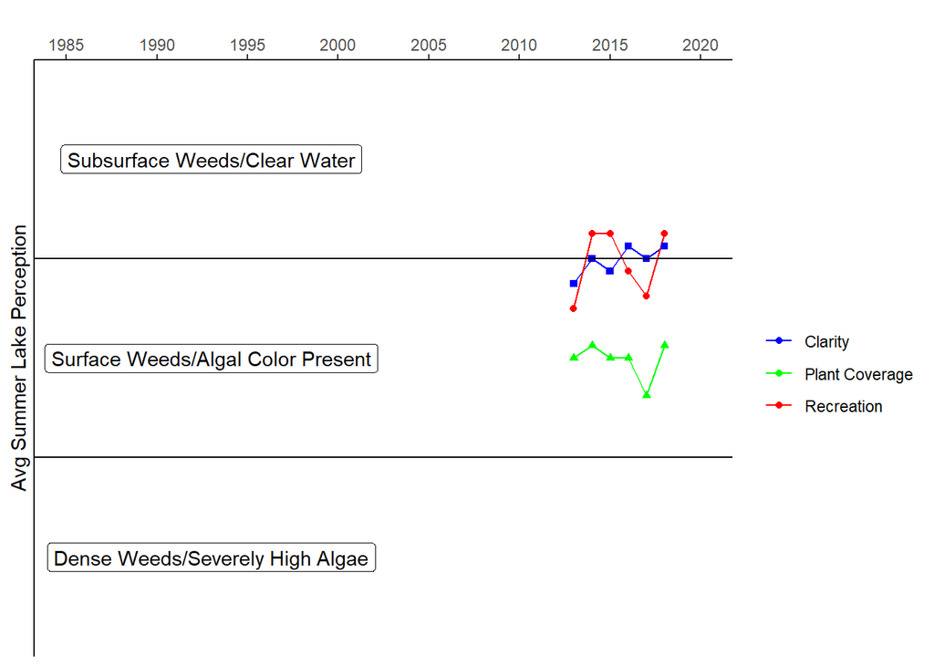

## Big Bowman Pond - In-Season Analysis

#### In Season Water Clarity

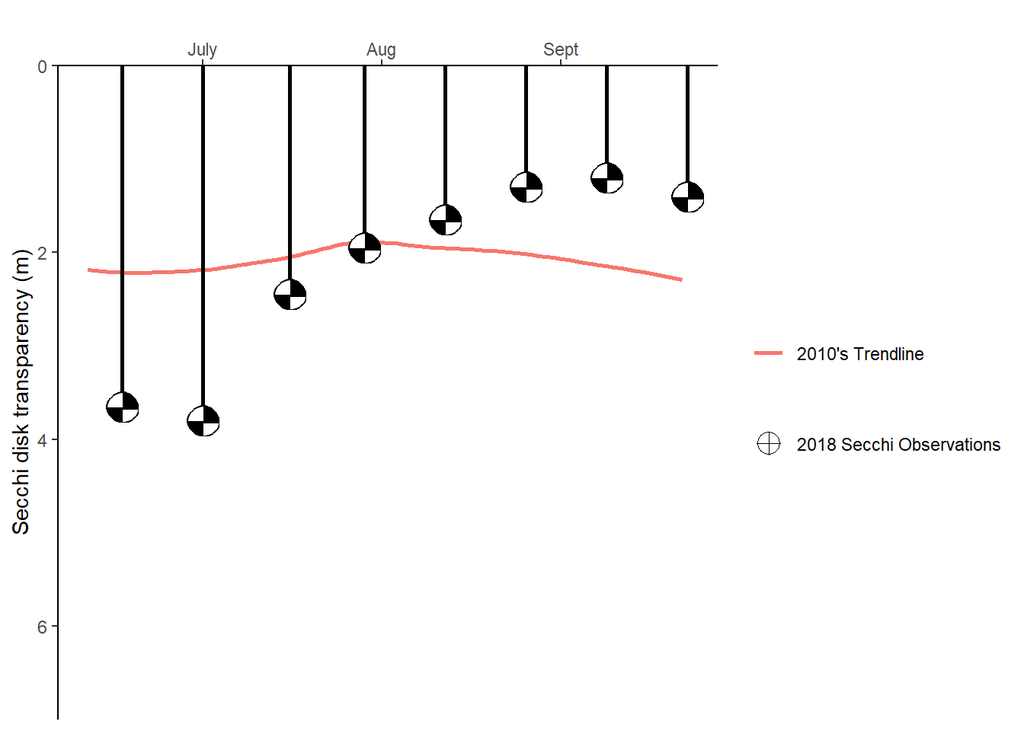

#### In Season Water Temperature

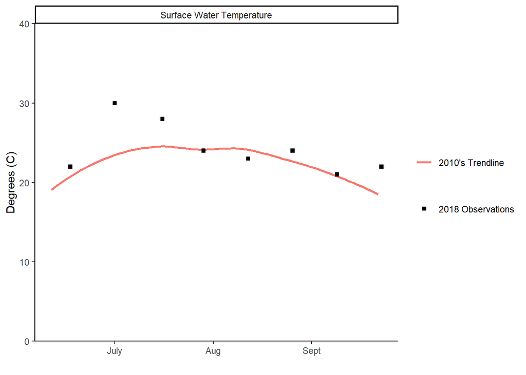

### Big Bowman Pond – Lake Scorecard

```
## [1] "Absent"
```

[output not shown]

| Aquatic Invasive Species | Absent |
| --- | --- |